# KCNJ11/ABCC8: do T2D and AD share a causal variant?

Fine-mapping and colocalisation at the sulfonylurea-target locus

Author

Dave Bridges

Published

October 29, 2026

## Why this analysis

The drug-target layer of the fasting vs 2 h glucose analysis found that T2D liability acting through the KATP channel (KCNJ11/ABCC8, the sulfonylurea target) was associated with higher AD risk (OR 1.27 per log-odds of T2D, SlopeHunter-corrected Bellenguez). At the variant level the estimate rests on two of seven instruments: **rs5215** in KCNJ11 (a proxy for the E23K coding variant, rs5219) and the low-frequency **rs113264182** (nearest gene NCR3LG1). The amylin result fell apart in the same view, being driven by one variant with its own AD association.

A drug-target effect predicts that the variant raising T2D risk through the channel is the **same** variant that raises AD risk. A nearby but distinct AD signal predicts two different causal variants. This notebook tests that at the locus:

1. **The instruments variant by variant** for the KATP channel and, for comparison, the amylin receptor.
2. **Regional association** for T2D and AD, coloured by LD with rs5215.
3. **LD among the lead variants**, including rs5219 (E23K).
4. **Colocalisation** (`coloc.abf`, one causal variant per trait) between T2D and each AD dataset, with a prior sensitivity analysis, and **SuSiE-based colocalisation** allowing more than one causal variant.
5. **Heterogeneity** among the seven KATP instruments.
6. **Kunkle at the variant level** for the leads.
7. The chr17q21 (MLX) signal behind the amylin estimate.
8. **KATP specificity:** AD per mmol/L of 2 h glucose for KATP against GCK and genome-wide beta-cell variants.
9. **The vascular KATP channel** (ABCC9/KCNJ8): a regional lookup.

Data come from the targets pipeline store (`_targets/`): Suzuki 2024 T2D (European), Bellenguez 2022 AD raw and SlopeHunter-corrected, Kunkle 2019 AD. All positions are GRCh37. LD is from the 1000 Genomes European panel (503 people) the pipeline uses everywhere.

```r
library(dplyr)
library(tidyr)
library(readr)
library(ggplot2)
library(data.table)
library(knitr)
library(targets)

# Pipeline helpers: ld_matrix(), resolve_plink2(), harmonise conventions.
for (f in list.files("pipeline/R", full.names = TRUE)) source(f)
cfg    <- yaml::read_yaml("pipeline/config.yml")
plink2 <- resolve_plink2(cfg$paths$plink2)
bfile  <- cfg$paths$ld_bfile
bim    <- tar_read(ld_bim)

# ---- settings: edit here -------------------------------------------------------------------
region   <- list(chr = "11", start = 17.0e6, end = 17.8e6)   # KCNJ11 17.41 Mb, ABCC8 17.41-17.50 Mb
leads    <- c("rs5215", "rs5219", "rs113264182")
datasets <- c(t2d    = "gwas_t2d_suzuki_eur",
              ad_sh  = "gwas_sh_ad_bellenguez",
              ad_raw = "gwas_ad_bellenguez",
              ad_kun = "gwas_ad_kunkle")
labels   <- c(t2d = "T2D (Suzuki 2024)", ad_sh = "AD, Bellenguez (SlopeHunter)",
              ad_raw = "AD, Bellenguez (raw)", ad_kun = "AD, Kunkle (clinical)")
# Case/control counts (for coloc's case fraction); T2D uses the per-variant effective N with s = 0.5.
cc <- list(ad_sh = c(n = 487511, s = 85934 / 487511), ad_raw = c(n = 487511, s = 85934 / 487511),
           ad_kun = c(n = 63926, s = 21982 / 63926))
# --------------------------------------------------------------------------------------------

theme_fm <- theme_minimal(base_size = 14) +
  theme(legend.position = "bottom", panel.grid.minor = element_blank(), strip.text = element_text(face = "bold"))
```

## 1. The instruments, variant by variant

Each point is one drug-target instrument: its effect on T2D (x) against its effect on AD (y), both on the T2D risk allele, with 95% intervals (SlopeHunter-corrected Bellenguez). Labels give the nearest protein-coding gene and the rsID; where the nearest gene is not the drug-target gene the variant was assigned to (within 100 kb), the target is shown in brackets. The solid red line through the origin is the class estimate from the drug-target layer (`drug_target_results.csv`), which allows for the residual LD between variants, so it is not simply a fit to the points as drawn.

The amylin receptor panel is the comparison case: its estimate rests on one variant (rs34779241, nearest gene PLEKHH3) with an AD association of its own, while the CALCR variant is flat. That is the pattern of a nearby variant acting on AD independently of the target, which is why the KATP locus gets the closer look below.

```r
class_labels <- c(katp_secretagogue = "KATP channel (sulfonylureas)", amylin = "Amylin receptor")
dt_snps <- read_csv("results/pipeline/contrast/drug_target_snps.csv", show_col_types = FALSE) |>
  filter(set == "primary", outcome == "ad_bellenguez", arm == "slopehunter", drug_class %in% names(class_labels)) |>
  mutate(class = class_labels[drug_class],
         label = if_else(nearest_gene == drug_target_gene, sprintf("%s\n%s", nearest_gene, SNP),
                         sprintf("%s [%s]\n%s", nearest_gene, drug_target_gene, SNP)))
dt_lines <- read_csv("results/pipeline/contrast/drug_target_results.csv", show_col_types = FALSE) |>
  filter(set == "primary", outcome == "ad_bellenguez", arm == "slopehunter", level == "class",
         trait == "AD (log-OR)", target %in% names(class_labels)) |>
  transmute(class = class_labels[target], slope = b,
            txt = sprintf("OR %.2f (%.2f, %.2f)\nper log-odds T2D", exp(b), exp(b - 1.96 * se), exp(b + 1.96 * se)))
```

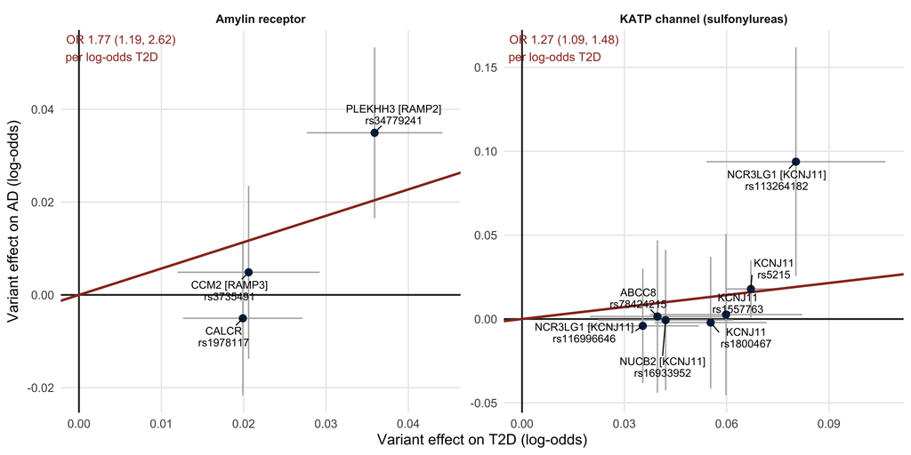

```r
ggplot(dt_snps, aes(beta_t2d, beta_y)) +
  # zero axes, drawn first and heavier than the grid
  geom_hline(yintercept = 0, colour = "grey15", linewidth = 0.8) +
  geom_vline(xintercept = 0, colour = "grey15", linewidth = 0.8) +
  geom_errorbar(aes(ymin = beta_y - 1.96 * se_y, ymax = beta_y + 1.96 * se_y), colour = "grey70", width = 0) +
  geom_errorbar(aes(xmin = beta_t2d - 1.96 * se_t2d, xmax = beta_t2d + 1.96 * se_t2d), colour = "grey70",
                width = 0, orientation = "y") +
  geom_abline(data = dt_lines, aes(slope = slope, intercept = 0), colour = "#9a3324", linewidth = 1.1) +
  geom_point(colour = "#00274c", size = 2.8) +
  ggrepel::geom_text_repel(aes(label = label), size = 3.6, lineheight = 0.9, min.segment.length = 0,
                           box.padding = 0.5, seed = 1) +
  geom_text(data = dt_lines, aes(x = -Inf, y = Inf, label = txt), hjust = -0.05, vjust = 1.2, size = 4,
            colour = "#9a3324") +
  facet_wrap(~ class, scales = "free") +
  expand_limits(x = 0, y = 0) +
  labs(x = "Variant effect on T2D (log-odds)", y = "Variant effect on AD (log-odds)") +
  theme_fm + theme(panel.grid.major.y = element_line())
```

```r
dt_snps |>
  arrange(class, desc(abs(beta_y / se_y))) |>
  transmute(Class = class, SNP, `Nearest gene` = nearest_gene, `Target gene` = drug_target_gene,
            `T2D log-OR` = sprintf("%.3f", beta_t2d), `AD log-OR (SE)` = sprintf("%.3f (%.3f)", beta_y, se_y),
            `AD p` = signif(2 * pnorm(-abs(beta_y / se_y)), 2),
            `Fasting glucose` = sprintf("%.3f", beta_fg), `2 h glucose` = sprintf("%.3f", beta_2h)) |>
  kable(caption = "Glucose columns: mmol/L per T2D risk allele.")
```

Glucose columns: mmol/L per T2D risk allele.

| Class | SNP | Nearest gene | Target gene | T2D log-OR | AD log-OR (SE) | AD p | Fasting glucose | 2 h glucose |
| --- | --- | --- | --- | --- | --- | --- | --- | --- |
| Amylin receptor | rs34779241 | PLEKHH3 | RAMP2 | 0.036 | 0.035 (0.009) | 0.0002 | -0.003 | 0.034 |
| Amylin receptor | rs1978117 | CALCR | CALCR | 0.020 | -0.005 (0.008) | 0.5500 | -0.001 | 0.020 |
| Amylin receptor | rs3735491 | CCM2 | RAMP3 | 0.021 | 0.005 (0.009) | 0.6100 | 0.002 | 0.021 |
| KATP channel (sulfonylureas) | rs113264182 | NCR3LG1 | KCNJ11 | 0.080 | 0.094 (0.035) | 0.0070 | 0.007 | 0.062 |
| KATP channel (sulfonylureas) | rs5215 | KCNJ11 | KCNJ11 | 0.067 | 0.018 (0.009) | 0.0390 | 0.002 | 0.038 |
| KATP channel (sulfonylureas) | rs116996646 | NCR3LG1 | KCNJ11 | 0.035 | -0.004 (0.017) | 0.8100 | 0.001 | 0.029 |
| KATP channel (sulfonylureas) | rs1557763 | KCNJ11 | KCNJ11 | 0.060 | 0.003 (0.025) | 0.9100 | 0.002 | 0.028 |
| KATP channel (sulfonylureas) | rs1800467 | KCNJ11 | KCNJ11 | 0.055 | -0.002 (0.020) | 0.9200 | 0.001 | 0.035 |
| KATP channel (sulfonylureas) | rs78424215 | ABCC8 | ABCC8 | 0.040 | 0.001 (0.023) | 0.9500 | -0.012 | 0.011 |
| KATP channel (sulfonylureas) | rs16933952 | NUCB2 | KCNJ11 | 0.042 | -0.001 (0.021) | 0.9800 | 0.001 | 0.007 |

## 2. Regional association

All four datasets are aligned to the LD panel’s counted allele (so the signed LD below applies to them directly). Palindromic variants (A/T, C/G) are dropped, since the Kunkle file has no allele frequencies to resolve their strand.

```r
in_region <- function(g) g[as.character(chr) == region$chr & pos >= region$start & pos <= region$end]
align_to_bim <- function(g) {
  m <- merge(g, bim[, .(SNP, a1, a2)], by = "SNP")
  m <- m[(ea == a1 & oa == a2) | (ea == a2 & oa == a1)]
  m[ea != a1, `:=`(beta = -beta, eaf = 1 - eaf)]
  m[!paste0(a1, a2) %chin% c("AT", "TA", "CG", "GC")][, .(SNP, pos, beta, se, p, eaf, n)]
}
reg <- purrr::imap(datasets, \(tgt, k) align_to_bim(in_region(tar_read_raw(tgt))))
common <- Reduce(intersect, purrr::map(reg, "SNP"))
reg <- purrr::map(reg, \(d) d[SNP %chin% common][order(pos)])

R <- ld_matrix(common, bim, bfile, plink2)          # signed r on the counted allele (a1)
common <- rownames(R)
reg <- purrr::map(reg, \(d) d[match(common, SNP)])
r2_lead <- R[, "rs5215"]^2

long <- purrr::imap_dfr(reg, \(d, k) tibble(dataset = labels[[k]], SNP = d$SNP, pos = d$pos, p = d$p)) |>
  mutate(dataset = factor(dataset, levels = labels), r2 = r2_lead[SNP],
         r2_bin = cut(r2, c(-Inf, 0.2, 0.4, 0.6, 0.8, Inf), labels = c("<0.2", "0.2-0.4", "0.4-0.6", "0.6-0.8", ">0.8")))
genes <- tibble(gene = c("NCR3LG1", "KCNJ11", "ABCC8"), start = c(17373e3, 17406.8e3, 17414.4e3),
                end = c(17398e3, 17410.9e3, 17498.4e3))   # GRCh37, approximate
```

1694 variants are present in all four datasets.

```r
ggplot(long, aes(pos / 1e6, -log10(p))) +
  annotate("rect", xmin = genes$start / 1e6, xmax = genes$end / 1e6, ymin = -Inf, ymax = Inf,
           alpha = 0.08, fill = "#00274c") +
  geom_point(aes(colour = r2_bin), size = 1.3) +
  geom_point(data = filter(long, SNP %in% leads), shape = 21, size = 3.5, colour = "black", stroke = 1) +
  ggrepel::geom_text_repel(data = filter(long, SNP %in% leads), aes(label = SNP), size = 3.3, seed = 1) +
  facet_wrap(~ dataset, ncol = 1, scales = "free_y") +
  scale_colour_manual(values = c("<0.2" = "grey70", "0.2-0.4" = "#9fb4cc", "0.4-0.6" = "#4f7ba6",
                                 "0.6-0.8" = "#ffcb05", ">0.8" = "#9a3324")) +
  labs(x = "Chromosome 11 position (Mb, GRCh37); shaded: NCR3LG1, KCNJ11, ABCC8",
       y = expression(-log[10](p)), colour = "r² with rs5215") +
  theme_fm
```

[figure not shown]

```r
top <- purrr::imap_dfr(reg, \(d, k) d[which.min(p)] |> as_tibble() |> mutate(dataset = labels[[k]])) |>
  transmute(Dataset = dataset, `Top variant` = SNP, `Position` = pos, p = signif(p, 2),
            `r² with rs5215` = round(r2_lead[`Top variant`], 2))
kable(top, caption = "Strongest variant in the region, per dataset")
```

Strongest variant in the region, per dataset

| Dataset | Top variant | Position | p | r² with rs5215 |
| --- | --- | --- | --- | --- |
| T2D (Suzuki 2024) | rs5215 | 17408630 | 0.00000 | 1.00 |
| AD, Bellenguez (SlopeHunter) | rs4757568 | 17715891 | 0.00062 | 0.01 |
| AD, Bellenguez (raw) | rs147692648 | 17749336 | 0.00130 | 0.00 |
| AD, Kunkle (clinical) | rs2229007 | 17793385 | 0.00120 | 0.00 |

## 3. LD among the lead variants

```r
ld_set <- intersect(unique(c(leads, top$`Top variant`)), common)
round(R[ld_set, ld_set]^2, 3) |> kable(caption = "r² (1000 Genomes European)")
```

r² (1000 Genomes European)

|  | rs5215 | rs5219 | rs113264182 | rs4757568 | rs147692648 | rs2229007 |
| --- | --- | --- | --- | --- | --- | --- |
| rs5215 | 1.000 | 1.000 | 0.018 | 0.006 | 0.000 | 0.001 |
| rs5219 | 1.000 | 1.000 | 0.018 | 0.006 | 0.000 | 0.001 |
| rs113264182 | 0.018 | 0.018 | 1.000 | 0.000 | 0.000 | 0.003 |
| rs4757568 | 0.006 | 0.006 | 0.000 | 1.000 | 0.019 | 0.034 |
| rs147692648 | 0.000 | 0.000 | 0.000 | 0.019 | 1.000 | 0.001 |
| rs2229007 | 0.001 | 0.001 | 0.003 | 0.034 | 0.001 | 1.000 |

## 4. Colocalisation

**Single causal variant (`coloc.abf`).** Five hypotheses: H0 no association, H1 T2D only, H2 AD only, H3 both but different causal variants, H4 both with a shared causal variant. A drug-target effect predicts H4; a nearby independent AD signal predicts H3. Default priors (p1 = p2 = 1×10⁻⁴, p12 = 1×10⁻⁵).

```r
as_coloc <- function(d, k) {
  maf <- pmin(reg$t2d$eaf, 1 - reg$t2d$eaf)           # Kunkle has no frequencies; use T2D's
  if (k == "t2d") list(snp = d$SNP, beta = d$beta, varbeta = d$se^2, type = "cc", N = d$n, s = 0.5, MAF = maf)
  else list(snp = d$SNP, beta = d$beta, varbeta = d$se^2, type = "cc", N = cc[[k]][["n"]], s = cc[[k]][["s"]], MAF = maf)
}
abf <- purrr::map(c("ad_sh", "ad_raw", "ad_kun"), \(k)
  suppressMessages(coloc::coloc.abf(as_coloc(reg$t2d, "t2d"), as_coloc(reg[[k]], k)))) |>
  setNames(c("ad_sh", "ad_raw", "ad_kun"))
```

```
PP.H0.abf PP.H1.abf PP.H2.abf PP.H3.abf PP.H4.abf
 7.08e-63  9.04e-01  5.05e-64  6.44e-02  3.18e-02
[1] "PP abf for shared variant: 3.18%"
```

```
PP.H0.abf PP.H1.abf PP.H2.abf PP.H3.abf PP.H4.abf
 7.24e-63  9.24e-01  3.52e-64  4.49e-02  3.06e-02
[1] "PP abf for shared variant: 3.06%"
```

```
PP.H0.abf PP.H1.abf PP.H2.abf PP.H3.abf PP.H4.abf
 7.19e-63  9.19e-01  5.38e-64  6.87e-02  1.28e-02
[1] "PP abf for shared variant: 1.28%"
```

```r
purrr::imap_dfr(abf, \(r, k) as_tibble(as.list(r$summary)) |> mutate(Comparison = paste("T2D vs", labels[[k]]))) |>
  transmute(Comparison, SNPs = nsnps, across(PP.H0.abf:PP.H4.abf, \(x) round(x, 3))) |>
  rename_with(\(x) sub("PP\\.(H[0-4])\\.abf", "\\1", x)) |>
  kable(caption = "Posterior probabilities")
```

Posterior probabilities

| Comparison | SNPs | H0 | H1 | H2 | H3 | H4 |
| --- | --- | --- | --- | --- | --- | --- |
| T2D vs AD, Bellenguez (SlopeHunter) | 1694 | 0 | 0.904 | 0 | 0.064 | 0.032 |
| T2D vs AD, Bellenguez (raw) | 1694 | 0 | 0.924 | 0 | 0.045 | 0.031 |
| T2D vs AD, Kunkle (clinical) | 1694 | 0 | 0.919 | 0 | 0.069 | 0.013 |

```r
# If a shared variant is supported, which one? Posterior for each SNP being the shared causal variant (H4).
purrr::imap_dfr(abf, \(r, k) r$results |> as_tibble() |> slice_max(SNP.PP.H4, n = 3) |>
                  transmute(Comparison = labels[[k]], SNP = snp, `PP (shared causal | H4)` = round(SNP.PP.H4, 3))) |>
  kable()
```

| Comparison | SNP | PP (shared causal \| H4) |
| --- | --- | --- |
| AD, Bellenguez (SlopeHunter) | rs5215 | 0.736 |
| AD, Bellenguez (SlopeHunter) | rs5219 | 0.263 |
| AD, Bellenguez (SlopeHunter) | rs2074314 | 0.001 |
| AD, Bellenguez (raw) | rs5215 | 0.735 |
| AD, Bellenguez (raw) | rs5219 | 0.264 |
| AD, Bellenguez (raw) | rs2074314 | 0.001 |
| AD, Kunkle (clinical) | rs5215 | 0.725 |
| AD, Kunkle (clinical) | rs5219 | 0.274 |
| AD, Kunkle (clinical) | rs2074314 | 0.001 |

**Prior sensitivity.** How the conclusion depends on p12, the prior probability that a variant is causal for both traits. The usual guidance treats H4 as robust only if it stays high for p12 down to about 5×10⁻⁶.

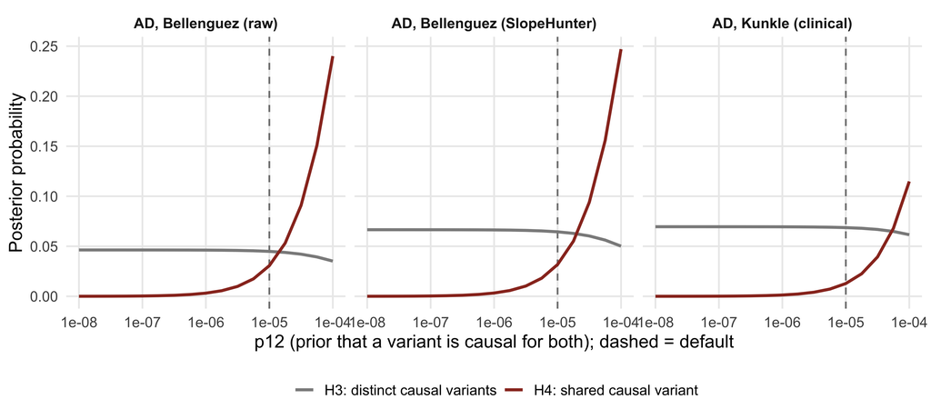

```r
# Only H4's prior involves p12, so changing p12 rescales PP(H4) by new/old p12 and renormalises.
p12_grid <- 10^seq(-8, -4, by = 0.25)
sens <- purrr::imap_dfr(abf, \(r, k) {
  pp <- r$summary[paste0("PP.H", 0:4, ".abf")]
  purrr::map_dfr(p12_grid, \(p12) {
    w <- pp * c(1, 1, 1, 1, p12 / 1e-5); w <- w / sum(w)
    tibble(p12 = p12, H3 = w[[4]], H4 = w[[5]])
  }) |> mutate(dataset = labels[[k]])
}) |> pivot_longer(c(H3, H4), names_to = "hypothesis", values_to = "pp")

ggplot(sens, aes(p12, pp, colour = hypothesis)) +
  geom_vline(xintercept = 1e-5, linetype = "dashed", colour = "grey50") +
  geom_line(linewidth = 1.1) +
  facet_wrap(~ dataset) +
  scale_x_log10() +
  scale_colour_manual(values = c(H3 = "grey55", H4 = "#9a3324"),
                      labels = c(H3 = "H3: distinct causal variants", H4 = "H4: shared causal variant")) +
  labs(x = "p12 (prior that a variant is causal for both); dashed = default", y = "Posterior probability",
       colour = NULL) +
  theme_fm
```

**More than one causal variant (SuSiE).** `coloc.abf` assumes one causal variant per trait. SuSiE fine-maps each trait into 95% credible sets using the LD matrix, and colocalisation is then tested between credible sets, so it needs at least one credible set **in each trait**. It is run on the two AD datasets with ordinary GWAS statistics (raw Bellenguez and Kunkle). The SlopeHunter-corrected statistics are a weighted difference of two GWAS and do not satisfy SuSiE’s summary-statistic model, so they are left out. The LD comes from 503 reference genomes, not the GWAS samples.

```r
ss_input <- function(d, k) { x <- c(as_coloc(d, k), list(LD = R)); x$N <- median(x$N); x }
ss_ad <- purrr::map(c(ad_raw = "ad_raw", ad_kun = "ad_kun"), \(k)
  tryCatch(coloc::runsusie(ss_input(reg[[k]], k), maxit = 1000), error = function(e) e))
purrr::imap_dfr(ss_ad, \(f, k) {
  if (inherits(f, "error")) return(tibble(Trait = labels[[k]], `Credible sets` = NA_integer_, note = conditionMessage(f)))
  tibble(Trait = labels[[k]], `Credible sets` = length(f$sets$cs),
         `Max PIP` = round(max(f$pip), 2), `Variant with max PIP` = names(f$pip)[which.max(f$pip)])
}) |> kable(caption = "SuSiE fine-mapping of AD in the region")
```

SuSiE fine-mapping of AD in the region

| Trait | Credible sets | Max PIP | Variant with max PIP |
| --- | --- | --- | --- |
| AD, Bellenguez (raw) | 0 | 0.05 | rs147692648 |
| AD, Kunkle (clinical) | 0 | 0.05 | rs2229007 |

With no AD credible set, there is no AD signal for SuSiE to colocalise with T2D, so the multi-variant analysis cannot add to `coloc.abf` here.

## 5. Heterogeneity among the seven KATP instruments

If the KATP channel drives AD through T2D liability, every instrument’s AD effect should be proportional to its T2D effect. Cochran’s Q, generalised for the residual LD between instruments (they were clumped at r² < 0.1): $Q = (\hat\beta_Y - \hat\theta\hat\beta_X)^\top \Omega^{-1} (\hat\beta_Y - \hat\theta\hat\beta_X)$ with $\Omega_{jk} = \sigma_{Yj}\sigma_{Yk} r_{jk}$.

```r
katp <- read_csv("results/pipeline/contrast/drug_target_snps.csv", show_col_types = FALSE) |>
  filter(set == "primary", drug_class == "katp_secretagogue")
het <- katp |> group_by(outcome, arm) |> group_modify(\(x, ...) {
  Rk <- ld_matrix(x$SNP, bim, bfile, plink2); x <- x[match(rownames(Rk), x$SNP), ]
  s <- if_else(x$ea == bim$a1[match(x$SNP, bim$SNP)], 1, -1); Rk <- Rk * outer(s, s)
  Oi <- solve(outer(x$se_y, x$se_y) * Rk)
  th <- drop(t(x$beta_t2d) %*% Oi %*% x$beta_y) / drop(t(x$beta_t2d) %*% Oi %*% x$beta_t2d)
  e <- x$beta_y - th * x$beta_t2d; Q <- drop(t(e) %*% Oi %*% e)
  tibble(SNPs = nrow(x), theta = th, Q = Q, df = nrow(x) - 1, p_het = pchisq(Q, nrow(x) - 1, lower.tail = FALSE))
}) |> ungroup()
het |> transmute(Outcome = paste(outcome, arm), SNPs, `θ (log-OR AD per log-odds T2D)` = round(theta, 3),
                 Q = round(Q, 2), df, `p (heterogeneity)` = signif(p_het, 2)) |> kable()
```

| Outcome | SNPs | θ (log-OR AD per log-odds T2D) | Q | df | p (heterogeneity) |
| --- | --- | --- | --- | --- | --- |
| ad_bellenguez raw | 7 | 0.220 | 5.36 | 6 | 0.50 |
| ad_bellenguez slopehunter | 7 | 0.238 | 6.32 | 6 | 0.39 |
| ad_kunkle raw | 5 | 0.005 | 5.07 | 4 | 0.28 |
| ad_uffelmann_cc raw | 5 | 0.101 | 3.25 | 4 | 0.52 |
| ad_uffelmann_newc raw | 5 | 0.252 | 4.22 | 4 | 0.38 |

## 6. Kunkle at the variant level

```r
lead_tab <- katp |>
  filter(SNP %in% c("rs5215", "rs113264182")) |>
  transmute(SNP, nearest_gene, Outcome = paste(outcome, arm), b = beta_y, se = se_y,
            p = 2 * pnorm(-abs(beta_y / se_y)), beta_t2d)
lead_tab |>
  transmute(SNP, `Nearest gene` = nearest_gene, Outcome,
            `AD log-OR (95% CI)` = sprintf("%.3f (%.3f, %.3f)", b, b - 1.96 * se, b + 1.96 * se),
            p = signif(p, 2), `Wald ratio (per log-odds T2D)` = round(b / beta_t2d, 2)) |>
  arrange(SNP, Outcome) |>
  kable()
```

| SNP | Nearest gene | Outcome | AD log-OR (95% CI) | p | Wald ratio (per log-odds T2D) |
| --- | --- | --- | --- | --- | --- |
| rs113264182 | NCR3LG1 | ad_bellenguez raw | 0.082 (0.016, 0.148) | 0.015 | 1.02 |
| rs113264182 | NCR3LG1 | ad_bellenguez slopehunter | 0.094 (0.026, 0.162) | 0.007 | 1.17 |
| rs113264182 | NCR3LG1 | ad_kunkle raw | -0.047 (-0.165, 0.070) | 0.430 | -0.59 |
| rs5215 | KCNJ11 | ad_bellenguez raw | 0.017 (0.001, 0.034) | 0.041 | 0.26 |
| rs5215 | KCNJ11 | ad_bellenguez slopehunter | 0.018 (0.001, 0.035) | 0.039 | 0.27 |
| rs5215 | KCNJ11 | ad_kunkle raw | 0.017 (-0.012, 0.046) | 0.250 | 0.25 |
| rs5215 | KCNJ11 | ad_uffelmann_cc raw | 0.007 (-0.004, 0.019) | 0.230 | 0.11 |
| rs5215 | KCNJ11 | ad_uffelmann_newc raw | 0.008 (-0.011, 0.027) | 0.430 | 0.11 |

## Reading the results: KCNJ11

**There is no detectable AD signal at the locus to colocalise.** `coloc.abf` puts about 90% on H1 (a T2D signal, no AD signal) in all three comparisons; H4 (shared causal variant) is 1–3% and H3 (distinct variants) 4–7%. The strongest AD variants in the region (p ≈ 10⁻³) lie about 300 kb away at 17.7 Mb and are unlinked to rs5215 (r² ≤ 0.01). SuSiE finds no AD credible set. This is what a real but small effect looks like as much as a null: an AD association of p = 0.04 at rs5215 is far too weak for colocalisation, which needs a clear signal in both traits. So colocalisation neither confirms nor refutes a shared variant here; it is underpowered by design for an effect this size.

**rs5215 behaves the same in every AD dataset.** Its AD log-OR is 0.017–0.018 in raw and SlopeHunter-corrected Bellenguez and 0.017 in Kunkle, giving the same Wald ratio (0.25–0.27 per log-odds of T2D) in all three. Kunkle’s interval includes zero only because it is smaller. If the variant were colocalising, this conditional posterior is where it would show: given a shared variant (H4), rs5215 and its perfect proxy rs5219 (E23K, r² = 1.00) carry essentially all of the probability.

**rs113264182 does not replicate.** It is independent of rs5215 (r² = 0.02), positive in Bellenguez (0.094, p = 0.007) but negative in Kunkle (−0.047). It drove the KATP class estimate up in Bellenguez and, missing or reversed, pulled it to zero in Kunkle. The null Kunkle class estimate is therefore about this variant, not about rs5215.

**The seven instruments are consistent with one effect** (heterogeneity p = 0.39 in SlopeHunter Bellenguez, 0.50 raw, 0.28 Kunkle), so the five flat variants do not contradict the two positive ones at this precision.

**Overall.** The best-supported reading is a small effect carried by the E23K haplotype (rs5215/rs5219), consistent in direction and size across all three AD datasets but individually only nominal. The KATP class estimate of OR 1.27 overstates it because of rs113264182, which looks like noise. Colocalisation cannot settle whether rs5215 is causal for AD at this effect size; a larger clinical AD dataset, or E23K carriers in a cohort with cognitive follow-up, would.

## 7. A second post-load locus? The chr17q21 (MLX) signal

The amylin-receptor estimate rested on one variant, rs34779241, labelled RAMP2 because RAMP2 was the only drug-target gene within 100 kb. It is in fact a proxy (r² = 0.89) for **rs676387**, Suzuki 2024’s index variant for the T2D locus named *MLX* (obesity cluster). In GTEx v8 it is an eQTL for TUBG2 (22 tissues), CNTNAP1 (strongest in pancreas) and several other genes, but not for RAMP2. Like the KCNJ11 variant, the T2D signal raises 2 h glucose with no fasting effect. The strongest AD association nearby, however, sits on a partly correlated haplotype (lead rs12450136, r² ≈ 0.3) with no 2 h glucose effect.

So the question is whether one causal variant raises T2D risk, 2 h glucose and AD together (a second post-load locus), or whether AD is driven by a separate nearby variant that the T2D instrument picks up through LD (pleiotropy). Here the AD signal is strong enough (p ≈ 10⁻⁵) for colocalisation to have power. T2D vs 2 h glucose is included as a positive control: both should share the index variant.

```r
region17 <- list(chr = "17", start = 40.4e6, end = 41.2e6)
leads17  <- c("rs676387", "rs34779241", "rs12450136")
datasets17 <- c(t2d = "gwas_t2d_suzuki_eur", glu2h = "gwas_glu2h_chen", fg = "gwas_fg_chen",
                ad_sh = "gwas_sh_ad_bellenguez", ad_raw = "gwas_ad_bellenguez", ad_kun = "gwas_ad_kunkle")
labels17 <- c(t2d = "T2D (Suzuki 2024)", glu2h = "2 h glucose (Chen 2021)", fg = "Fasting glucose (Chen 2021)",
              ad_sh = labels[["ad_sh"]], ad_raw = labels[["ad_raw"]], ad_kun = labels[["ad_kun"]])
quant_n <- c(glu2h = 63396, fg = 200622)

in17 <- function(g) g[as.character(chr) == region17$chr & pos >= region17$start & pos <= region17$end]
reg17 <- purrr::map(datasets17, \(tgt) align_to_bim(in17(tar_read_raw(tgt))))
common17 <- Reduce(intersect, purrr::map(reg17, "SNP"))
R17 <- ld_matrix(common17, bim, bfile, plink2)
common17 <- rownames(R17)
reg17 <- purrr::map(reg17, \(d) d[match(common17, SNP)])

long17 <- purrr::imap_dfr(reg17, \(d, k) tibble(dataset = labels17[[k]], SNP = d$SNP, pos = d$pos, p = d$p)) |>
  mutate(dataset = factor(dataset, levels = labels17), r2 = R17[SNP, "rs676387"]^2,
         r2_bin = cut(r2, c(-Inf, 0.2, 0.4, 0.6, 0.8, Inf), labels = c("<0.2", "0.2-0.4", "0.4-0.6", "0.6-0.8", ">0.8")))
genes17 <- tibble(gene = c("MLX", "TUBG2/PLEKHH3", "RAMP2"), start = c(40719086, 40811323, 40910465),
                  end = c(40725257, 40829048, 40915059))
```

821 variants are present in all six datasets.

```r
ggplot(long17, aes(pos / 1e6, -log10(p))) +
  annotate("rect", xmin = genes17$start / 1e6, xmax = genes17$end / 1e6, ymin = -Inf, ymax = Inf,
           alpha = 0.12, fill = "#00274c") +
  geom_point(aes(colour = r2_bin), size = 1.3) +
  geom_point(data = filter(long17, SNP %in% leads17), shape = 21, size = 3.5, colour = "black", stroke = 1) +
  ggrepel::geom_text_repel(data = filter(long17, SNP %in% leads17), aes(label = SNP), size = 3.3, seed = 1) +
  facet_wrap(~ dataset, ncol = 1, scales = "free_y") +
  scale_colour_manual(values = c("<0.2" = "grey70", "0.2-0.4" = "#9fb4cc", "0.4-0.6" = "#4f7ba6",
                                 "0.6-0.8" = "#ffcb05", ">0.8" = "#9a3324")) +
  labs(x = "Chromosome 17 position (Mb, GRCh37); shaded: MLX, TUBG2/PLEKHH3, RAMP2",
       y = expression(-log[10](p)), colour = "r² with rs676387") +
  theme_fm
```

[figure not shown]

```r
purrr::imap_dfr(reg17, \(d, k) d[which.min(p)] |> as_tibble() |> mutate(dataset = labels17[[k]])) |>
  transmute(Dataset = dataset, `Top variant` = SNP, Position = pos, p = signif(p, 2),
            `r² with rs676387` = round(R17[SNP, "rs676387"]^2, 2),
            `r² with rs12450136` = round(R17[SNP, "rs12450136"]^2, 2)) |>
  kable(caption = "Strongest variant in the region, per dataset")
```

Strongest variant in the region, per dataset

| Dataset | Top variant | Position | p | r² with rs676387 | r² with rs12450136 |
| --- | --- | --- | --- | --- | --- |
| T2D (Suzuki 2024) | rs676387 | 40706273 | 0.0e+00 | 1.00 | 0.28 |
| 2 h glucose (Chen 2021) | rs66918837 | 40799633 | 3.2e-06 | 0.85 | 0.31 |
| Fasting glucose (Chen 2021) | rs111351217 | 41163974 | 2.0e-04 | 0.09 | 0.02 |
| AD, Bellenguez (SlopeHunter) | rs72826906 | 40641172 | 5.6e-06 | 0.27 | 0.93 |
| AD, Bellenguez (raw) | rs72826906 | 40641172 | 6.1e-05 | 0.27 | 0.93 |
| AD, Kunkle (clinical) | rs138312553 | 41023343 | 2.0e-04 | 0.00 | 0.00 |

```r
maf17 <- pmin(reg17$t2d$eaf, 1 - reg17$t2d$eaf)
as_coloc17 <- function(k) {
  d <- reg17[[k]]
  base <- list(snp = d$SNP, beta = d$beta, varbeta = d$se^2, MAF = maf17)
  if (k == "t2d") c(base, list(type = "cc", N = d$n, s = 0.5))
  else if (k %in% names(quant_n)) c(base, list(type = "quant", N = quant_n[[k]]))
  else c(base, list(type = "cc", N = cc[[k]][["n"]], s = cc[[k]][["s"]]))
}
pairs17 <- tribble(~a, ~b,
  "t2d", "glu2h",            # positive control: should share the index variant
  "t2d", "ad_sh", "t2d", "ad_raw", "t2d", "ad_kun",
  "glu2h", "ad_sh", "glu2h", "ad_raw", "glu2h", "ad_kun")
abf17 <- purrr::pmap(pairs17, \(a, b) suppressMessages(coloc::coloc.abf(as_coloc17(a), as_coloc17(b))))
```

```
PP.H0.abf PP.H1.abf PP.H2.abf PP.H3.abf PP.H4.abf
 1.67e-15  6.87e-02  7.42e-16  2.97e-02  9.02e-01
[1] "PP abf for shared variant: 90.2%"
```

```
PP.H0.abf PP.H1.abf PP.H2.abf PP.H3.abf PP.H4.abf
 1.62e-15  6.65e-02  3.86e-15  1.58e-01  7.76e-01
[1] "PP abf for shared variant: 77.6%"
```

```
PP.H0.abf PP.H1.abf PP.H2.abf PP.H3.abf PP.H4.abf
 8.74e-15  3.60e-01  3.39e-15  1.39e-01  5.01e-01
[1] "PP abf for shared variant: 50.1%"
```

```
PP.H0.abf PP.H1.abf PP.H2.abf PP.H3.abf PP.H4.abf
 2.11e-14  8.69e-01  2.79e-15  1.15e-01  1.61e-02
[1] "PP abf for shared variant: 1.61%"
```

```
PP.H0.abf PP.H1.abf PP.H2.abf PP.H3.abf PP.H4.abf
   0.1040    0.0461    0.2470    0.1100    0.4940
[1] "PP abf for shared variant: 49.4%"
```

```
PP.H0.abf PP.H1.abf PP.H2.abf PP.H3.abf PP.H4.abf
   0.3850    0.1710    0.1490    0.0661    0.2290
[1] "PP abf for shared variant: 22.9%"
```

```
PP.H0.abf PP.H1.abf PP.H2.abf PP.H3.abf PP.H4.abf
  0.60700   0.27000   0.08040   0.03580   0.00622
[1] "PP abf for shared variant: 0.622%"
```

```r
coloc17 <- purrr::map2_dfr(abf17, seq_len(nrow(pairs17)), \(r, i) {
  top <- r$results |> slice_max(SNP.PP.H4, n = 1)
  as_tibble(as.list(r$summary)) |>
    mutate(Comparison = paste(labels17[[pairs17$a[i]]], "vs", labels17[[pairs17$b[i]]]),
           `Top shared variant (if H4)` = sprintf("%s (%.2f)", top$snp, top$SNP.PP.H4))
})
coloc17 |>
  transmute(Comparison, across(PP.H0.abf:PP.H4.abf, \(x) round(x, 3)), `Top shared variant (if H4)`) |>
  rename_with(\(x) sub("PP\\.(H[0-4])\\.abf", "\\1", x)) |>
  kable(caption = "coloc.abf posterior probabilities (default priors)")
```

coloc.abf posterior probabilities (default priors)

| Comparison | H0 | H1 | H2 | H3 | H4 | Top shared variant (if H4) |
| --- | --- | --- | --- | --- | --- | --- |
| T2D (Suzuki 2024) vs 2 h glucose (Chen 2021) | 0.000 | 0.069 | 0.000 | 0.030 | 0.902 | rs676387 (0.34) |
| T2D (Suzuki 2024) vs AD, Bellenguez (SlopeHunter) | 0.000 | 0.067 | 0.000 | 0.158 | 0.776 | rs676387 (0.22) |
| T2D (Suzuki 2024) vs AD, Bellenguez (raw) | 0.000 | 0.360 | 0.000 | 0.139 | 0.501 | rs676387 (0.22) |
| T2D (Suzuki 2024) vs AD, Kunkle (clinical) | 0.000 | 0.869 | 0.000 | 0.115 | 0.016 | rs676387 (0.20) |
| 2 h glucose (Chen 2021) vs AD, Bellenguez (SlopeHunter) | 0.104 | 0.046 | 0.247 | 0.110 | 0.494 | rs66918837 (0.33) |
| 2 h glucose (Chen 2021) vs AD, Bellenguez (raw) | 0.385 | 0.171 | 0.149 | 0.066 | 0.229 | rs66918837 (0.29) |
| 2 h glucose (Chen 2021) vs AD, Kunkle (clinical) | 0.607 | 0.270 | 0.080 | 0.036 | 0.006 | rs66918837 (0.14) |

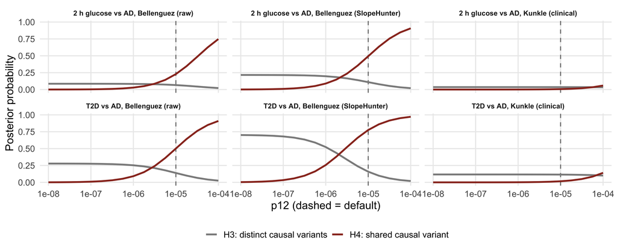

```r
sens17 <- purrr::map2_dfr(abf17, seq_len(nrow(pairs17)), \(r, i) {
  pp <- r$summary[paste0("PP.H", 0:4, ".abf")]
  purrr::map_dfr(p12_grid, \(p12) { w <- pp * c(1, 1, 1, 1, p12 / 1e-5); w <- w / sum(w)
    tibble(p12 = p12, H3 = w[[4]], H4 = w[[5]]) }) |>
    mutate(comparison = paste(sub(" \\(.*", "", labels17[[pairs17$a[i]]]), "vs", labels17[[pairs17$b[i]]]))
}) |>
  filter(grepl("AD", comparison)) |>
  pivot_longer(c(H3, H4), names_to = "hypothesis", values_to = "pp")
ggplot(sens17, aes(p12, pp, colour = hypothesis)) +
  geom_vline(xintercept = 1e-5, linetype = "dashed", colour = "grey50") +
  geom_line(linewidth = 1.1) +
  facet_wrap(~ comparison, nrow = 2) +
  scale_x_log10() +
  scale_colour_manual(values = c(H3 = "grey55", H4 = "#9a3324"),
                      labels = c(H3 = "H3: distinct causal variants", H4 = "H4: shared causal variant")) +
  labs(x = "p12 (dashed = default)", y = "Posterior probability", colour = NULL) +
  theme_fm + theme(strip.text = element_text(size = 9))
```

**One AD signal or two?** `coloc.abf` assumes a single causal variant per trait, and SuSiE (which relaxes that) did not converge with the reference LD here. A simpler, more robust check is an approximate conditional analysis on the two candidate leads: the T2D index rs676387 and the top AD variant rs72826906 (r² ≈ 0.27). For z-scores $z_1, z_2$ with signed LD $r$, the association of variant 1 conditional on variant 2 is $z_{1\mid 2} = (z_1 - r z_2)/\sqrt{1 - r^2}$. If AD has one signal on the T2D haplotype, rs676387 should keep its AD association after conditioning on rs72826906; if AD’s signal is on the other haplotype, it should not.

```r
cond_pair <- function(k, s1, s2) {
  d <- reg17[[k]]; z <- setNames(d$beta / d$se, d$SNP); r <- R17[s1, s2]
  tibble(Trait = labels17[[k]], Variant = c(s1, s2),
         `z (marginal)` = c(z[[s1]], z[[s2]]),
         `z (conditional on the other)` = c((z[[s1]] - r * z[[s2]]) / sqrt(1 - r^2),
                                            (z[[s2]] - r * z[[s1]]) / sqrt(1 - r^2)))
}
purrr::map_dfr(c("t2d", "glu2h", "ad_sh", "ad_raw", "ad_kun"), cond_pair, s1 = "rs676387", s2 = "rs72826906") |>
  mutate(`p (marginal)` = signif(2 * pnorm(-abs(`z (marginal)`)), 2),
         `p (conditional)` = signif(2 * pnorm(-abs(`z (conditional on the other)`)), 2),
         across(starts_with("z ("), \(x) round(x, 2))) |>
  kable(caption = sprintf("Approximate conditional analysis (signed r = %.2f between the two variants, 1000 Genomes European)",
                          R17["rs676387", "rs72826906"]))
```

Approximate conditional analysis (signed r = -0.52 between the two variants, 1000 Genomes European)

| Trait | Variant | z (marginal) | z (conditional on the other) | p (marginal) | p (conditional) |
| --- | --- | --- | --- | --- | --- |
| T2D (Suzuki 2024) | rs676387 | 9.27 | 7.63 | 0.0e+00 | 0.0e+00 |
| T2D (Suzuki 2024) | rs72826906 | -5.29 | -0.55 | 1.0e-07 | 5.8e-01 |
| 2 h glucose (Chen 2021) | rs676387 | 4.12 | 4.38 | 3.8e-05 | 1.2e-05 |
| 2 h glucose (Chen 2021) | rs72826906 | -0.72 | 1.66 | 4.7e-01 | 9.7e-02 |
| AD, Bellenguez (SlopeHunter) | rs676387 | 3.96 | 1.87 | 7.5e-05 | 6.1e-02 |
| AD, Bellenguez (SlopeHunter) | rs72826906 | -4.54 | -2.91 | 5.6e-06 | 3.6e-03 |
| AD, Bellenguez (raw) | rs676387 | 3.38 | 1.51 | 7.1e-04 | 1.3e-01 |
| AD, Bellenguez (raw) | rs72826906 | -4.04 | -2.66 | 5.4e-05 | 7.7e-03 |
| AD, Kunkle (clinical) | rs676387 | 1.21 | 1.25 | 2.3e-01 | 2.1e-01 |
| AD, Kunkle (clinical) | rs72826906 | -0.28 | 0.41 | 7.8e-01 | 6.8e-01 |

### Reading the results: chr17q21

**T2D and 2 h glucose share one signal.** The positive control works: T2D and 2 h glucose colocalise (H4 = 0.90), and conditional on rs676387 the other haplotype’s T2D association disappears (p = 0.58). This is a post-load-specific T2D locus, as at KCNJ11.

**AD’s signal sits mostly on the other haplotype.** The strongest AD variant (rs72826906, p = 6×10⁻⁶ SlopeHunter-corrected) keeps its association after conditioning on the T2D index (p = 0.004), while the T2D index’s AD association drops from p = 8×10⁻⁵ to 0.06. rs72826906 has no T2D or 2 h glucose effect of its own once rs676387 is accounted for. So most of the AD association at this locus comes from a variant that does not act through T2D or post-load glucose; the T2D variant picks it up through LD (r² ≈ 0.27). A small residual AD effect on the T2D haplotype cannot be excluded.

**Why `coloc.abf` nonetheless leans to H4** (0.78 SlopeHunter-corrected, 0.50 raw): with a single causal variant assumed per trait, the AD evidence at the T2D haplotype (p ≈ 10⁻⁴) is enough for the default prior to favour sharing. The call is not robust: on the same posteriors, lowering p12 to 5×10⁻⁶ gives H4 ≈ 0.63 (SlopeHunter) and 0.33 (raw), and at 1×10⁻⁶ about 0.26 and 0.09. The conditional analysis, which allows two variants, is the more reliable guide here.

**Kunkle shows nothing at either variant** (p > 0.2), as with the amylin class estimate.

**Overall.** This locus is not the amylin receptor: the variant is a proxy for the *MLX*-region T2D index, is not an eQTL for RAMP2, and its AD association is largely explained by a neighbouring variant without glycaemic effects. It does not add a second post-load locus to KCNJ11.

## 8. Is the KATP effect on AD larger than its glucose effect predicts?

If the KATP channel affects AD through something other than glucose, KATP variants should give more AD per mmol/L of 2 h glucose than variants that raise glucose by other routes. The cleanest comparison is glucokinase (GCK), which acts in the same cell through a different step of the glucose-sensing pathway. The broader comparisons are the genome-wide beta-cell variants (Suzuki clusters) and all primary T2D instruments. The KCNJ11/ABCC8 (chr11 16.9–17.9 Mb) and GCK (chr7 43.7–44.7 Mb) regions are left out of the genome-wide sets.

All estimates use the same T2D selection (Suzuki 2024). For each group, AD and 2 h glucose are each regressed on the T2D effect (LD-aware GLS for the cis classes, IVW with multiplicative random effects genome-wide), and the AD effect per mmol/L of 2 h glucose is their ratio: $\hat\theta_{\text{mmol}} = \hat\theta_{AD}/\hat\theta_{2h}$, with $\text{SE} \approx |\hat\theta_{\text{mmol}}|\sqrt{(\text{SE}_{AD}/\hat\theta_{AD})^2 + (\text{SE}_{2h}/\hat\theta_{2h})^2}$. This treats MAGIC and the AD GWAS as independent samples. KATP minus comparator differences are tested with $z = \Delta/\sqrt{\text{SE}_1^2 + \text{SE}_2^2}$, since the groups share no variants. Two KATP sensitivity rows: without rs113264182 (the variant that flips sign in Kunkle), and rs5215 alone (Wald ratios).

```r
# Sections 8-9 add the Uffelmann 2026 replication outcomes (post-freeze, raw; SlopeHunter not identified)
datasets_all <- c(datasets, uff_newc = "gwas_ad_uffelmann_newc", uff_cc = "gwas_ad_uffelmann_cc")
labels_all   <- c(labels, uff_newc = "AD, Uffelmann new cohorts (independent)",
                  uff_cc = "AD, Uffelmann clinical only")
katp_reg  <-\(d) filter(d, !(chr == 11 & between(pos, 16.9e6, 17.9e6)), !(chr == 7 & between(pos, 43.7e6, 44.7e6)))
ivw_mre   <- function(bx, by, se) { f <- wls_mre(by, cbind(bx), se); c(b = unname(f$b[[1]]), se = sqrt(f$V[1, 1])) }
cis_gls   <- function(x) {
  Rk <- ld_matrix(x$SNP, bim, bfile, plink2); x <- x[match(rownames(Rk), x$SNP), ]
  s <- if_else(x$ea == bim$a1[match(x$SNP, bim$SNP)], 1, -1); Rk <- Rk * outer(s, s)
  if (nrow(x) == 1) Rk <- matrix(1)
  a <- gls_ratio(x$beta_t2d, x$beta_y, x$se_y, Rk); g <- gls_ratio(x$beta_t2d, x$beta_2h, x$se_2h, Rk)
  tibble(n = nrow(x), b_ad = a[["b"]], se_ad = a[["se"]], b_2h = g[["b"]], se_2h = g[["se"]])
}
dt_all <- read_csv("results/pipeline/contrast/drug_target_snps.csv", show_col_types = FALSE) |>
  filter(set == "primary", drug_class %in% c("katp_secretagogue", "glucokinase"))
cis_groups <- bind_rows(
  dt_all |> filter(drug_class == "katp_secretagogue") |> mutate(group = "KATP (KCNJ11/ABCC8), all variants"),
  dt_all |> filter(drug_class == "katp_secretagogue", SNP != "rs113264182") |> mutate(group = "KATP without rs113264182"),
  dt_all |> filter(SNP == "rs5215") |> mutate(group = "KATP, rs5215 (E23K proxy) alone"),
  dt_all |> filter(drug_class == "glucokinase") |> mutate(group = "Glucokinase (GCK)")) |>
  group_by(outcome, arm, group) |> group_modify(\(x, ...) cis_gls(x)) |> ungroup()

iod <- read_csv("results/pipeline/contrast/instrument_outcome_data.csv", show_col_types = FALSE) |>
  filter(set == "primary") |> katp_reg()
gw_groups <- bind_rows(
  iod |> filter(grepl("^Beta cell", cluster)) |> mutate(group = "Beta cell, genome-wide"),
  iod |> filter(cluster == "Beta cell -PI") |> mutate(group = "Beta cell -PI"),
  iod |> filter(cluster == "Beta cell +PI") |> mutate(group = "Beta cell +PI"),
  iod |> mutate(group = "All primary T2D instruments")) |>
  group_by(outcome, arm, group) |>
  group_modify(\(x, ...) { a <- ivw_mre(x$beta_t2d, x$beta_y, x$se_y); g <- ivw_mre(x$beta_t2d, x$beta_2h, x$se_2h)
    tibble(n = nrow(x), b_ad = a[["b"]], se_ad = a[["se"]], b_2h = g[["b"]], se_2h = g[["se"]]) }) |> ungroup()

spec <- bind_rows(cis_groups, gw_groups) |>
  mutate(b_mmol = b_ad / b_2h, se_mmol = abs(b_mmol) * sqrt((se_ad / b_ad)^2 + (se_2h / b_2h)^2),
         outcome_lab = factor(labels_all[c(ad_bellenguez.slopehunter = "ad_sh", ad_bellenguez.raw = "ad_raw",
                                           ad_kunkle.raw = "ad_kun", ad_uffelmann_newc.raw = "uff_newc",
                                           ad_uffelmann_cc.raw = "uff_cc")[paste(outcome, arm, sep = ".")]],
                              levels = labels_all),
         group = factor(group, levels = c("KATP (KCNJ11/ABCC8), all variants", "KATP without rs113264182",
                                          "KATP, rs5215 (E23K proxy) alone", "Glucokinase (GCK)",
                                          "Beta cell, genome-wide", "Beta cell -PI", "Beta cell +PI",
                                          "All primary T2D instruments")))
```

```r
spec |>
  mutate(katp = grepl("^KATP", group),
         lo = exp(b_mmol - 1.96 * se_mmol), hi = exp(b_mmol + 1.96 * se_mmol)) |>
  filter(paste(outcome, arm) %in% c("ad_bellenguez slopehunter", "ad_uffelmann_newc raw", "ad_uffelmann_cc raw")) |>
  ggplot(aes(exp(b_mmol), forcats::fct_rev(group), colour = katp)) +
  geom_vline(xintercept = 1, colour = "grey15", linewidth = 0.8) +
  geom_errorbar(aes(xmin = lo, xmax = hi), width = 0.2, orientation = "y", linewidth = 0.8) +
  geom_point(size = 3) +
  geom_text(aes(x = Inf, label = sprintf("%.2f (%.2f, %.2f) n=%d", exp(b_mmol), lo, hi, n)),
            hjust = 1, vjust = -0.6, size = 3.2, colour = "grey20") +
  scale_x_log10() +
  scale_colour_manual(values = c(`TRUE` = "#9a3324", `FALSE` = "#00274c"), guide = "none") +
  coord_cartesian(xlim = c(0.6, 4.5)) +
  facet_wrap(~ outcome_lab, nrow = 1) +
  labs(x = "AD odds ratio per mmol/L of genetically raised 2 h glucose", y = NULL) +
  theme_fm
```

[figure not shown]

```r
spec |>
  transmute(Outcome = outcome_lab, Group = group, `Variants` = n,
            `AD log-OR per log-odds T2D` = sprintf("%.3f (%.3f)", b_ad, se_ad),
            `2 h glucose per log-odds T2D (mmol/L)` = sprintf("%.2f", b_2h),
            `AD OR per mmol/L 2 h glucose (95% CI)` = sprintf("%.2f (%.2f, %.2f)", exp(b_mmol),
                                                               exp(b_mmol - 1.96 * se_mmol), exp(b_mmol + 1.96 * se_mmol))) |>
  arrange(Outcome, Group) |>
  kable()
```

| Outcome | Group | Variants | AD log-OR per log-odds T2D | 2 h glucose per log-odds T2D (mmol/L) | AD OR per mmol/L 2 h glucose (95% CI) |
| --- | --- | --- | --- | --- | --- |
| AD, Bellenguez (SlopeHunter) | KATP (KCNJ11/ABCC8), all variants | 7 | 0.238 (0.077) | 0.57 | 1.52 (1.15, 2.02) |
| AD, Bellenguez (SlopeHunter) | KATP without rs113264182 | 6 | 0.172 (0.082) | 0.55 | 1.37 (1.01, 1.85) |
| AD, Bellenguez (SlopeHunter) | KATP, rs5215 (E23K proxy) alone | 1 | 0.267 (0.129) | 0.56 | 1.61 (0.98, 2.63) |
| AD, Bellenguez (SlopeHunter) | Glucokinase (GCK) | 11 | 0.106 (0.084) | 1.40 | 1.08 (0.96, 1.21) |
| AD, Bellenguez (SlopeHunter) | Beta cell, genome-wide | 53 | 0.040 (0.024) | 0.34 | 1.12 (0.98, 1.29) |
| AD, Bellenguez (SlopeHunter) | Beta cell -PI | 25 | 0.066 (0.045) | 0.41 | 1.18 (0.94, 1.47) |
| AD, Bellenguez (SlopeHunter) | Beta cell +PI | 28 | 0.031 (0.029) | 0.32 | 1.10 (0.92, 1.32) |
| AD, Bellenguez (SlopeHunter) | All primary T2D instruments | 271 | 0.015 (0.017) | 0.26 | 1.06 (0.93, 1.20) |
| AD, Bellenguez (raw) | KATP (KCNJ11/ABCC8), all variants | 7 | 0.220 (0.074) | 0.57 | 1.47 (1.12, 1.93) |
| AD, Bellenguez (raw) | KATP without rs113264182 | 6 | 0.163 (0.079) | 0.55 | 1.34 (1.00, 1.80) |
| AD, Bellenguez (raw) | KATP, rs5215 (E23K proxy) alone | 1 | 0.256 (0.125) | 0.56 | 1.58 (0.98, 2.54) |
| AD, Bellenguez (raw) | Glucokinase (GCK) | 11 | 0.047 (0.081) | 1.40 | 1.03 (0.92, 1.16) |
| AD, Bellenguez (raw) | Beta cell, genome-wide | 60 | 0.023 (0.022) | 0.35 | 1.07 (0.94, 1.21) |
| AD, Bellenguez (raw) | Beta cell -PI | 29 | 0.034 (0.042) | 0.41 | 1.09 (0.89, 1.33) |
| AD, Bellenguez (raw) | Beta cell +PI | 31 | 0.020 (0.028) | 0.33 | 1.06 (0.90, 1.26) |
| AD, Bellenguez (raw) | All primary T2D instruments | 286 | -0.012 (0.016) | 0.28 | 0.96 (0.86, 1.07) |
| AD, Kunkle (clinical) | KATP (KCNJ11/ABCC8), all variants | 5 | 0.005 (0.169) | 0.57 | 1.01 (0.57, 1.80) |
| AD, Kunkle (clinical) | KATP without rs113264182 | 4 | 0.054 (0.181) | 0.55 | 1.10 (0.58, 2.10) |
| AD, Kunkle (clinical) | KATP, rs5215 (E23K proxy) alone | 1 | 0.252 (0.221) | 0.56 | 1.57 (0.71, 3.45) |
| AD, Kunkle (clinical) | Glucokinase (GCK) | 9 | -0.100 (0.151) | 1.40 | 0.93 (0.75, 1.15) |
| AD, Kunkle (clinical) | Beta cell, genome-wide | 55 | 0.014 (0.037) | 0.36 | 1.04 (0.85, 1.28) |
| AD, Kunkle (clinical) | Beta cell -PI | 24 | 0.026 (0.071) | 0.41 | 1.07 (0.76, 1.50) |
| AD, Kunkle (clinical) | Beta cell +PI | 31 | 0.011 (0.052) | 0.35 | 1.03 (0.77, 1.38) |
| AD, Kunkle (clinical) | All primary T2D instruments | 261 | 0.018 (0.025) | 0.28 | 1.06 (0.90, 1.27) |
| AD, Uffelmann new cohorts (independent) | KATP (KCNJ11/ABCC8), all variants | 5 | 0.252 (0.093) | 0.55 | 1.58 (1.11, 2.25) |
| AD, Uffelmann new cohorts (independent) | KATP without rs113264182 | 5 | 0.252 (0.093) | 0.55 | 1.58 (1.11, 2.25) |
| AD, Uffelmann new cohorts (independent) | KATP, rs5215 (E23K proxy) alone | 1 | 0.113 (0.145) | 0.56 | 1.22 (0.73, 2.04) |
| AD, Uffelmann new cohorts (independent) | Glucokinase (GCK) | 8 | 0.322 (0.101) | 1.43 | 1.25 (1.09, 1.44) |
| AD, Uffelmann new cohorts (independent) | Beta cell, genome-wide | 52 | 0.067 (0.029) | 0.34 | 1.22 (1.02, 1.45) |
| AD, Uffelmann new cohorts (independent) | Beta cell -PI | 22 | 0.034 (0.061) | 0.42 | 1.08 (0.81, 1.45) |
| AD, Uffelmann new cohorts (independent) | Beta cell +PI | 30 | 0.075 (0.034) | 0.32 | 1.26 (1.01, 1.57) |
| AD, Uffelmann new cohorts (independent) | All primary T2D instruments | 250 | 0.032 (0.019) | 0.27 | 1.12 (0.98, 1.29) |
| AD, Uffelmann clinical only | KATP (KCNJ11/ABCC8), all variants | 5 | 0.101 (0.056) | 0.55 | 1.20 (0.98, 1.47) |
| AD, Uffelmann clinical only | KATP without rs113264182 | 5 | 0.101 (0.056) | 0.55 | 1.20 (0.98, 1.47) |
| AD, Uffelmann clinical only | KATP, rs5215 (E23K proxy) alone | 1 | 0.106 (0.088) | 0.56 | 1.21 (0.88, 1.66) |
| AD, Uffelmann clinical only | Glucokinase (GCK) | 8 | 0.088 (0.062) | 1.43 | 1.06 (0.98, 1.16) |
| AD, Uffelmann clinical only | Beta cell, genome-wide | 60 | 0.047 (0.018) | 0.35 | 1.14 (1.03, 1.27) |
| AD, Uffelmann clinical only | Beta cell -PI | 28 | 0.054 (0.032) | 0.41 | 1.14 (0.98, 1.33) |
| AD, Uffelmann clinical only | Beta cell +PI | 32 | 0.046 (0.023) | 0.33 | 1.15 (1.00, 1.32) |
| AD, Uffelmann clinical only | All primary T2D instruments | 289 | 0.036 (0.012) | 0.28 | 1.14 (1.04, 1.25) |

```r
ref <- spec |> filter(group == "KATP (KCNJ11/ABCC8), all variants") |>
  select(outcome, arm, k_ad = b_ad, kse_ad = se_ad, k_mmol = b_mmol, kse_mmol = se_mmol)
spec |> filter(!grepl("^KATP", group)) |> inner_join(ref, by = c("outcome", "arm")) |>
  transmute(Outcome = outcome_lab, `KATP vs` = group,
            `Δ per log-odds T2D` = sprintf("%.2f", k_ad - b_ad),
            `p (per log-odds T2D)` = signif(2 * pnorm(-abs((k_ad - b_ad) / sqrt(kse_ad^2 + se_ad^2))), 2),
            `Δ per mmol/L 2 h glucose` = sprintf("%.2f", k_mmol - b_mmol),
            `p (per mmol/L)` = signif(2 * pnorm(-abs((k_mmol - b_mmol) / sqrt(kse_mmol^2 + se_mmol^2))), 2)) |>
  arrange(Outcome, `KATP vs`) |>
  kable(caption = "KATP (all available variants) minus each comparator, log-OR scale")
```

KATP (all available variants) minus each comparator, log-OR scale

| Outcome | KATP vs | Δ per log-odds T2D | p (per log-odds T2D) | Δ per mmol/L 2 h glucose | p (per mmol/L) |
| --- | --- | --- | --- | --- | --- |
| AD, Bellenguez (SlopeHunter) | Glucokinase (GCK) | 0.13 | 0.2400 | 0.34 | 0.0280 |
| AD, Bellenguez (SlopeHunter) | Beta cell, genome-wide | 0.20 | 0.0130 | 0.30 | 0.0580 |
| AD, Bellenguez (SlopeHunter) | Beta cell -PI | 0.17 | 0.0530 | 0.26 | 0.1600 |
| AD, Bellenguez (SlopeHunter) | Beta cell +PI | 0.21 | 0.0110 | 0.32 | 0.0600 |
| AD, Bellenguez (SlopeHunter) | All primary T2D instruments | 0.22 | 0.0043 | 0.36 | 0.0210 |
| AD, Bellenguez (raw) | Glucokinase (GCK) | 0.17 | 0.1200 | 0.35 | 0.0190 |
| AD, Bellenguez (raw) | Beta cell, genome-wide | 0.20 | 0.0110 | 0.32 | 0.0370 |
| AD, Bellenguez (raw) | Beta cell -PI | 0.19 | 0.0300 | 0.30 | 0.0780 |
| AD, Bellenguez (raw) | Beta cell +PI | 0.20 | 0.0120 | 0.33 | 0.0450 |
| AD, Bellenguez (raw) | All primary T2D instruments | 0.23 | 0.0023 | 0.43 | 0.0042 |
| AD, Kunkle (clinical) | Glucokinase (GCK) | 0.10 | 0.6400 | 0.08 | 0.8000 |
| AD, Kunkle (clinical) | Beta cell, genome-wide | -0.01 | 0.9600 | -0.03 | 0.9200 |
| AD, Kunkle (clinical) | Beta cell -PI | -0.02 | 0.9100 | -0.05 | 0.8700 |
| AD, Kunkle (clinical) | Beta cell +PI | -0.01 | 0.9700 | -0.02 | 0.9500 |
| AD, Kunkle (clinical) | All primary T2D instruments | -0.01 | 0.9400 | -0.05 | 0.8600 |
| AD, Uffelmann new cohorts (independent) | Glucokinase (GCK) | -0.07 | 0.6100 | 0.23 | 0.2300 |
| AD, Uffelmann new cohorts (independent) | Beta cell, genome-wide | 0.19 | 0.0580 | 0.26 | 0.1900 |
| AD, Uffelmann new cohorts (independent) | Beta cell -PI | 0.22 | 0.0500 | 0.38 | 0.1100 |
| AD, Uffelmann new cohorts (independent) | Beta cell +PI | 0.18 | 0.0750 | 0.22 | 0.2900 |
| AD, Uffelmann new cohorts (independent) | All primary T2D instruments | 0.22 | 0.0210 | 0.34 | 0.0780 |
| AD, Uffelmann clinical only | Glucokinase (GCK) | 0.01 | 0.8800 | 0.12 | 0.2800 |
| AD, Uffelmann clinical only | Beta cell, genome-wide | 0.05 | 0.3700 | 0.05 | 0.6800 |
| AD, Uffelmann clinical only | Beta cell -PI | 0.05 | 0.4700 | 0.05 | 0.6900 |
| AD, Uffelmann clinical only | Beta cell +PI | 0.06 | 0.3600 | 0.05 | 0.7200 |
| AD, Uffelmann clinical only | All primary T2D instruments | 0.06 | 0.2600 | 0.05 | 0.6500 |

## 9. The vascular KATP channel: ABCC9/KCNJ8 (SUR2/Kir6.1)

If channel-family biology matters, the other KATP channel, made of Kir6.1 and SUR2 (*KCNJ8* and *ABCC9*, chr12p12.1) and mainly found in vascular smooth muscle and pericytes, is worth a look. *ABCC9* variants, notably rs704180, have been linked to hippocampal sclerosis of aging. These subunits are not targets of the T2D drugs in the frozen drug-target map (sulfonylureas bind SUR1), so this is a regional lookup, not an MR. A null here would not count against the KCNJ11 result, since the two channels act in different tissues.

```r
region12 <- list(chr = "12", start = 21.6e6, end = 22.4e6)   # LDHB 21.79, KCNJ8 21.92, ABCC9 21.95-22.09 Mb
reg12 <- purrr::map(datasets_all, \(t) { x <- as.data.table(tar_read_raw(t))
  x[as.character(chr) == region12$chr & pos >= region12$start & pos <= region12$end] })
# Effective number of independent tests among common variants (Li & Ji 2005), for a region-wide threshold
snps12 <- reg12$ad_sh[eaf > 0.01 & eaf < 0.99 & SNP %in% bim$SNP, SNP]
ev12   <- abs(eigen(ld_matrix(snps12, bim, bfile, plink2), only.values = TRUE)$values)
meff12 <- sum((ev12 >= 1) + (ev12 - floor(ev12)))
```

```r
genes12 <- tibble(gene = c("LDHB", "KCNJ8", "ABCC9"), start = c(21.788e6, 21.918e6, 21.950e6),
                  end = c(21.811e6, 21.928e6, 22.094e6))
purrr::imap_dfr(reg12, \(x, k) x[, .(SNP, pos, p, dataset = labels_all[[k]])]) |>
  mutate(dataset = factor(dataset, levels = labels_all)) |>
  ggplot(aes(pos / 1e6, -log10(p))) +
  annotate("rect", xmin = genes12$start / 1e6, xmax = genes12$end / 1e6, ymin = -Inf, ymax = Inf,
           fill = "#FFCB05", alpha = 0.25) +
  geom_point(size = 0.8, colour = "grey45") +
  geom_point(data = \(d) filter(d, SNP %in% c("rs704180", "rs2077105")), colour = "#9a3324", size = 2.5) +
  geom_hline(yintercept = -log10(0.05 / meff12), linetype = "dashed", colour = "#2F65A7") +
  facet_wrap(~ dataset, ncol = 1, scales = "free_y") +
  labs(x = "chr12 position (Mb, GRCh37); shaded: LDHB, KCNJ8, ABCC9",
       y = expression(-log[10]~p),
       caption = sprintf("Red: rs704180 (ABCC9) and rs2077105 (T2D lead). Dashed: 0.05/%d effective tests.", round(meff12))) +
  theme_fm
```

[figure not shown]

```r
purrr::imap_dfr(reg12, \(x, k) {
  top <- x[order(p)][1]
  rbind(x[SNP %in% c("rs704180", "rs2077105")], top)[, .(Dataset = labels_all[[k]], SNP, pos, ea, oa,
                                                       beta = round(beta, 4), se = round(se, 4), p = format(p, digits = 2))] |>
    unique() }) |>
  kable(caption = sprintf("Named variants and the regional top hit per dataset; region-wide threshold p < %.1e",
                          0.05 / meff12))
```

Named variants and the regional top hit per dataset; region-wide threshold p < 2.1e-04

| Dataset | SNP | pos | ea | oa | beta | se | p |
| --- | --- | --- | --- | --- | --- | --- | --- |
| T2D (Suzuki 2024) | rs2077105 | 21839933 | A | G | 0.0306 | 0.0041 | 1.5e-13 |
| T2D (Suzuki 2024) | rs704180 | 21994111 | A | G | 0.0076 | 0.0037 | 4.0e-02 |
| AD, Bellenguez (SlopeHunter) | rs2077105 | 21839933 | G | A | -0.0129 | 0.0096 | 0.1779 |
| AD, Bellenguez (SlopeHunter) | rs704180 | 21994111 | G | A | 0.0112 | 0.0085 | 0.1859 |
| AD, Bellenguez (SlopeHunter) | rs117295320 | 21951107 | G | A | 0.1087 | 0.0321 | 0.0007 |
| AD, Bellenguez (raw) | rs2077105 | 21839933 | G | A | -0.0106 | 0.0093 | 0.25570 |
| AD, Bellenguez (raw) | rs704180 | 21994111 | G | A | 0.0078 | 0.0082 | 0.33730 |
| AD, Bellenguez (raw) | rs117295320 | 21951107 | G | A | 0.1071 | 0.0309 | 0.00052 |
| AD, Kunkle (clinical) | rs704180 | 21994111 | A | G | -0.0264 | 0.0143 | 0.0643 |
| AD, Kunkle (clinical) | rs2077105 | 21839933 | A | G | 0.0049 | 0.0163 | 0.7654 |
| AD, Kunkle (clinical) | rs2268861 | 22389474 | A | G | -0.0396 | 0.0152 | 0.0093 |
| AD, Uffelmann new cohorts (independent) | rs2077105 | 21839933 | A | G | -0.0146 | 0.0111 | 0.1884 |
| AD, Uffelmann new cohorts (independent) | rs704180 | 21994111 | A | G | -0.0079 | 0.0098 | 0.4186 |
| AD, Uffelmann new cohorts (independent) | rs10161132 | 21627287 | A | G | 0.0295 | 0.0100 | 0.0033 |
| AD, Uffelmann clinical only | rs704180 | 21994111 | A | G | -0.0072 | 0.0058 | 0.21830 |
| AD, Uffelmann clinical only | rs2077105 | 21839933 | A | G | -0.0022 | 0.0065 | 0.73700 |
| AD, Uffelmann clinical only | rs10161132 | 21627287 | A | G | 0.0209 | 0.0060 | 0.00044 |

From the GTEx v8 portal (single-tissue eQTLs, looked up for this section): rs2077105, the T2D lead, is an eQTL for *LDHB* (lung, oesophagus muscularis) and shows no *KCNJ8* or *ABCC9* association. rs704180 is an *ABCC9* eQTL in adrenal gland (p = 4×10⁻¹³) and caudate (p = 2×10⁻⁵).

## Reading the results: KATP specificity and SUR2

**KATP variants give more AD per unit of glucose than other glucose-raising variants, in Bellenguez.** Per mmol/L of genetically raised 2 h glucose, the KATP class gives an AD odds ratio of about 1.5 (SlopeHunter-corrected). GCK gives about 1.08 and the genome-wide beta-cell variants about 1.12. The difference from GCK is nominally significant (p ≈ 0.03), and from all T2D instruments p ≈ 0.02. Against the beta-cell variants it is borderline (p ≈ 0.06). Part of the gap comes from the glucose side: per unit of T2D liability, KATP variants raise 2 h glucose less than half as much as GCK variants (0.57 vs 1.40 mmol/L), so the same AD effect per unit of T2D becomes a larger effect per mmol/L. That is the pattern the channel hypothesis predicts. A glucose-only mechanism would predict equal per-mmol effects.

**Caveats.** The comparisons are nominal (p ≈ 0.02–0.06 across several comparators) and would not survive a strict multiple-testing correction. The ratio-of-ratios standard error assumes MAGIC and the AD GWAS are independent samples. And a larger AD effect per mmol/L is equally consistent with a KATP effect outside the brain that does not run through glucose (for example on insulin secretion itself). It shows that glucose alone does not explain the KATP effect, not that the extra effect acts in the brain.

**No AD signal at ABCC9/KCNJ8.** No variant in the 800 kb window passes the region-wide threshold in any AD dataset. The best Bellenguez hit (rs117295320, a 2% variant at the 5′ end of ABCC9, p ≈ 6×10⁻⁴) has no T2D association and does not reach significance in Kunkle. rs704180, the ABCC9 variant linked to hippocampal sclerosis of aging, shows nothing in either AD dataset (p = 0.19 SlopeHunter-corrected, 0.06 Kunkle, same direction). The region does have a genome-wide T2D signal (rs2077105, p = 1.5×10⁻¹³), but it is an *LDHB* eQTL with no KCNJ8/ABCC9 effect and only a weak, non-significant AD association. So there is no support for the vascular SUR2/Kir6.1 channel. As noted above, that neither helps nor hurts the KCNJ11 hypothesis.